# 41_inspection_plots

### [Partial Dependence Plot (PDP)](https://scikit-learn.org/stable/modules/generated/sklearn.inspection.plot_partial_dependence.html#sklearn.inspection.plot_partial_dependence)

- PDPs graph the dependence between a *target response* and a *set of input features*, marginalizing over the values of all other input features (the ‘complement’ features).
- We can interpret PD as a function of the input features of interest.
- Due to the limits of human perception the size of the set of input feature of interest must be small (usually 1-2). The input features of interest are usually chosen among the most important ones.

### [PDPs - 2D interactions](https://scikit-learn.org/stable/auto_examples/inspection/plot_partial_dependence.html#d-interaction-plots)

```
done in 1.018s
```

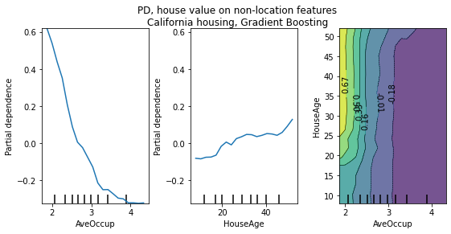

```python
features = ['AveOccup', 'HouseAge', ('AveOccup', 'HouseAge')]

tic = time()
_, ax = plt.subplots(ncols=3, figsize=(9, 4))
display = PPD(
    est, X_train,
    features, kind='average',
    n_jobs=3, grid_resolution=20,
    ax=ax)

print(f"done in {time() - tic:.3f}s")
display.figure_.suptitle(
    'PD, house value on non-location features\n'
    'California housing, Gradient Boosting')

display.figure_.subplots_adjust(wspace=0.4, hspace=0.3)
```

### [PDPs - 3D interactions](https://scikit-learn.org/stable/auto_examples/inspection/plot_partial_dependence.html#id7)

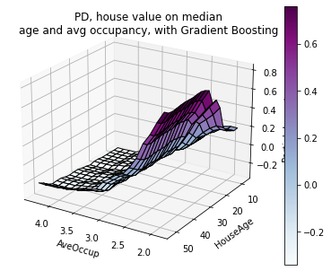

```python
import numpy as np
from mpl_toolkits.mplot3d import Axes3D
fig = plt.figure()

features = ('AveOccup', 'HouseAge')
pdp = PD(est, X_train,
         features=features,
         kind='average', grid_resolution=20)

XX, YY = np.meshgrid(pdp["values"][0],
                     pdp["values"][1])
Z = pdp.average[0].T
ax = Axes3D(fig)
surf = ax.plot_surface(XX, YY, Z, rstride=1, cstride=1,
                       cmap=plt.cm.BuPu, edgecolor='k')

ax.set_xlabel(features[0])
ax.set_ylabel(features[1])
ax.set_zlabel('Partial dependence')
# pretty init view
ax.view_init(elev=22, azim=122)
plt.colorbar(surf)
plt.suptitle('PD, house value on median\n'
             'age and avg occupancy, with Gradient Boosting')
plt.subplots_adjust(top=0.9)
```

### [Individual Conditional Expectation (ICE) Plot](https://scikit-learn.org/stable/modules/partial_dependence.html#individual-conditional-expectation-ice-plot)

- ICE plots can be built from the plot_partial_dependence function by using `kind='individual'`.
- ICE plots show the *dependence between a target function and an input feature*.
- Unlike a PDP, which shows the *average effect of the input feature*, an ICE plot visualizes the *dependence of the prediction on a feature for each sample **separately** - with one line per sample*.
- Due to the limits of human perception, only one input feature of interest is supported for ICE plots.
- While the PDPs are good at showing the average effect of the target features, they can obscure a heterogeneous relationship created by interactions.
- ICE plots will provide many more insights if interactions exist. For example, we see a linear relationship between median income and house price in the PD line. *The ICE lines show that there are exceptions*, where the house price remains constant in some ranges of the median income.
- It might not be easy to see the average effect of the input feature in an ICE plot. Consider using ICE plots alongside PDPs. They can be plotted together with `kind='both'`.

```
<sklearn.inspection._plot.partial_dependence.PartialDependenceDisplay at 0x7f875a87d8b0>
```

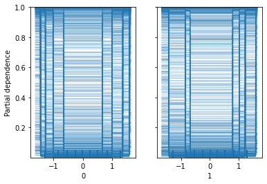

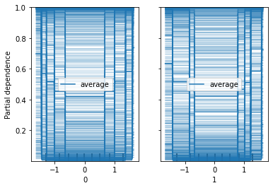

```python
from sklearn.datasets import make_hastie_10_2
from sklearn.ensemble import GradientBoostingClassifier
from sklearn.inspection import plot_partial_dependence

X, y = make_hastie_10_2(random_state=0)

clf = GradientBoostingClassifier(n_estimators=100, learning_rate=1.0,
    max_depth=1, random_state=0).fit(X, y)

features = [0, 1]
PPD(clf, X, features, kind='individual')
PPD(clf, X, features, kind='both')
```

### [Example: PDP & ICE plots, Cal Housing dataset](https://scikit-learn.org/stable/auto_examples/inspection/plot_partial_dependence.html)

```python
import pandas as pd
from sklearn.datasets import fetch_california_housing
from sklearn.model_selection import train_test_split as TTS

# center the targets to avoid gradient boosting init bias
# (gradient boosting with "recursion" doesn't account for
# the initial estimator (here the avg target, by default.)

cal_housing = fetch_california_housing()
X = pd.DataFrame(cal_housing.data,
                 columns=cal_housing.feature_names)
y = cal_housing.target
y -= y.mean()

X_train, X_test, y_train, y_test = TTS(
    X, y, test_size=0.1, random_state=0)
```

```python
# 1-way PD using a multilayer perceptron (MLP)
# and gradient boosting

from time import time
from sklearn.pipeline import make_pipeline
from sklearn.preprocessing import QuantileTransformer as QT
from sklearn.neural_network import MLPRegressor as MLPR

print("Training MLPRegressor...")
tic = time()
est = make_pipeline(QT(),
                    MLPR(hidden_layer_sizes=(50, 50),
                         learning_rate_init=0.01,
                         early_stopping=True)).fit(X_train,
                                                   y_train)
print(f"done in {time() - tic:.3f}s")
print(f"Test R2 score: {est.score(X_test, y_test):.2f}")
```

```
Training MLPRegressor...
done in 5.251s
Test R2 score: 0.80
```

```
done in 3.154s
```

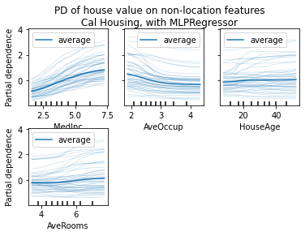

```python
import matplotlib.pyplot as plt
from sklearn.inspection import partial_dependence as PD
from sklearn.inspection import plot_partial_dependence as PPD

tic = time()
features = ['MedInc', 'AveOccup', 'HouseAge', 'AveRooms']

display = PPD(
    est, X_train, features,
    kind="both", subsample=50,
    n_jobs=3, grid_resolution=20, random_state=0)

print(f"done in {time() - tic:.3f}s")
display.figure_.suptitle(
    'PD of house value on non-location features\n'
    'Cal Housing, with MLPRegressor'
)
display.figure_.subplots_adjust(hspace=0.3)
```

```python
from sklearn.experimental import enable_hist_gradient_boosting  # noqa
from sklearn.ensemble import HistGradientBoostingRegressor as HGBR

tic = time()
est = HGBR().fit(X_train, y_train)
print(f"done in {time() - tic:.3f}s")
print(f"Test R2 score: {est.score(X_test, y_test):.2f}")
```

```
done in 0.565s
Test R2 score: 0.85
```

```
done in 2.210s
```

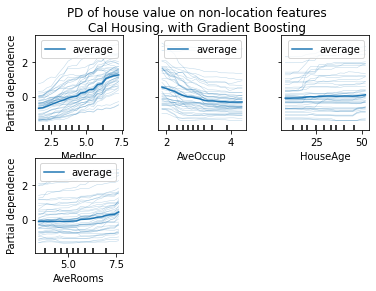

```python
tic = time()
display = PPD(
    est, X_train, features, kind="both", subsample=50,
    n_jobs=3, grid_resolution=20, random_state=0
)
print(f"done in {time() - tic:.3f}s")
display.figure_.suptitle(
    'PD of house value on non-location features\n'
    'Cal Housing, with Gradient Boosting'
)
display.figure_.subplots_adjust(wspace=0.4, hspace=0.3)
```

### PDP & ICE Plot Observations:

- The PDPs (thick blue line) indicate the median house price show 1) a linear relationship with median income (top left) 2) house price drops when the average occupants per household increases (top middle). 3) house age in a district does not have a strong influence on the (median) house price; (top right) 4) neither does the average rooms per household. (2nd row.)
- The ICE curves (light blue lines) complement the analysis: we can see that there are some exceptions, where the house price remain constant with median income and average occupants.
- While house age (top right) does not have a strong influence on the median house price, there seems to be exceptions where the house price increase when between the ages 15-25.
- Similar exceptions can be observed for the average number of rooms (bottom left). Therefore, ICE plots show some individual effect which are attenuated by taking the averages.
- In all plots, the tick marks on the x-axis represent the deciles of the feature values in the training data.
- MLPRegressor has *much smoother predictions* than HistGradientBoostingRegressor.
- If these features are correlated, we are creating *potential meaningless synthetic samples*.